# The Geography of the Undersea Internet network

2020209

2024-12-01

Word count: 3490

# Introduction

The network of undersea internet cables is responsible for 99% of data transfer internationally. In our digital age, fast and stable connections between countries are key facilitators of economic growth through global commerce, communication and technology. The number of cables between countries indicates their economic connection demonstrating increased need for security and reliably fast data transfer. Whilst rare, cables can be severed by earthquakes, maritime accidents and sabotage, making resilience an important requirement of the network. Installing cables is an expensive process making understanding of the spatial and structural characteristics of the network paramount to its efficient expansion.

Previous work identified that the number of landing points in a country is not defined by geographical characteristics but the network position of that country (Ross, 2014). Sugadev’s (2016) work highlights both the importance of India as a hub nation connecting Europe and Asia, as well as identify why this presents issues of vulnerability to the network. This report will explore both the connections to and the connections within the network through exploring:

**H1: The extent to which connection to the undersea internet network defined by factors other than geographical position.**

**H2: The extent to which structural role of countries within the network defined by factors other than geographical position.**

**H3: Identify the largest potential for connections between countries based on their demographic and geographic characteristics.**

The key findings of this report are that countries connected to the network have higher urban and internet populations than those which are not. Nations in the APEC trade group are also more likely to be in the network. Additionally, the location of countries is important for the connection status, with countries within Europe, Asia and South America being less likely to be part of the network. Strategically important countries of high network connectivity (hubs and intermediaries) are likely to have higher total populations (including higher internet populations and larger numbers of migration into the country), and are involved in some form of trade agreement (especially EU and APEC).

The most important connections in the network are found to be in Asia, between India, China and Bangladesh. Where there are connections here already, efforts to increase the resilience of the system by investing in new cable connections would be the most effective for the network.

Not only does this analysis identify the importance of certain countries in the network, but also the vulnerability countries face in the case of cable connections being broken. Providing useful insight into the areas which will benefit most from increased cable connections.

# Methods

### General setup

The analysis is setup by loading the required packages and then reading the cables and landing data from Tele-geography. This cable data is used to create a network of countries connected by the undersea cables. Groups are made where landing points are in the same country and are the nodes of the network. The edges are created between countries which are connected directly by cables. Countries which are not included in the network are added by name as unconnected nodes. Several data frames of geographical characterists are merged into one file by country names in the network. These include population, GDP, geographical location of centroid, trade group membership and coastline length relative to area. Network characteristics (degree centrality, page rank and betweenness) are used to identify the structural positions of countries within the network. Members of each of these positions (hub, intermediary and periphery) are labelled in the data-set. A seed is set to make the analysis reproducible.

```r
setwd("/Users/tomfeeney/Downloads/GDSA/Cities project /Second attempt ")
set.seed(123)

library(sf)
```

```r
library(leaflet)
library(ggplot2)
library(dplyr)
library(stringr)
library(igraph)
library(viridis)
library(RColorBrewer)
library(patchwork)
library(randomForest)
# loading the cable network files
cables= st_read("cables.json")
landings= st_read("landings.json")
# Extracting the country names from the landing points
landings <- landings %>%
  mutate(country = str_extract(name, "[^,]+$") %>%
           str_trim())
# Group landing points by cable to identify the country of each landing point
cable_connections <- landings %>%
  group_by(id) %>%
  summarise(countries = list(unique(country)))
# making both sf objects.
landings <- st_as_sf(landings, wkt = "geometry", crs = 4326)
cables <- st_as_sf(cables, wkt = "geometry", crs = 4326)

# joining the data
# Extract the endpoints of each cable as points
cable_endpoints <- cables %>%
  st_cast("POINT") %>%
  group_by(id) %>%                   # Group by cable ID
  filter(row_number() == 1 | row_number() == n()) %>%  # goes all the way through the data
  ungroup()

# Join cable endpoints with landing points based on proximity
landings_with_cables <- st_join(landings, cable_endpoints, join = st_nearest_feature)

# Extract country name from the 'name' column
landings_with_cables <- landings_with_cables %>%
  mutate(country = str_extract(name.x, "[^,]+$") %>%
           str_trim())

# grouping by country

Cable_network <- landings_with_cables %>%
  group_by(id.y) %>%
  summarise(countries = list(unique(country))) %>%  # Get unique countries per cable
  ungroup()

# Initialize an empty data frame to store edges
edges <- data.frame(from = character(), to = character(), cable_id = character())

# Loop through each cable and create pairs of countries as edges
for (i in 1:nrow(Cable_network)) {
  countries <- Cable_network$countries[[i]]
  cable_id <- Cable_network$id.y[i]

  # Create all possible pairs of countries for each cable
  if (length(countries) > 1) {  # Only if there’s more than one country
    combs <- combn(countries, 2)
    edges <- rbind(edges, data.frame(
      from = combs[1, ],
      to = combs[2, ],
      cable_id = cable_id
    ))
  }
}

# Create the graph from edges
Connected_countries_net <- graph_from_data_frame(edges, directed = FALSE)

# adding cable id as edge attribute.
E(Connected_countries_net)$cable_id <- edges$cable_id

# List of all countries (this should include all possible countries in your analysis)
all_countries <- unique(c(
  V(Connected_countries_net)$name,
  "Afghanistan", "Albania", "Algeria", "Andorra", "Angola", "Antigua and Barbuda", "Argentina", "Armenia",
  "Australia", "Austria", "Azerbaijan", "The Bahamas", "Bahrain", "Bangladesh", "Barbados", "Belarus",
  "Belgium", "Belize", "Benin", "Bhutan", "Bolivia", "Bosnia and Herzegovina", "Botswana", "Brazil", "Brunei",
  "Bulgaria", "Burkina Faso", "Burundi", "Cabo Verde", "Cambodia", "Cameroon", "Canada", "Central African Republic",
  "Chad", "Chile", "China", "Colombia", "Comoros", "Congo, Democratic Republic of the", "Congo, Republic of the",
  "Costa Rica", "Côte d’Ivoire", "Croatia", "Cuba", "Cyprus", "Czech Republic", "Denmark", "Djibouti", "Dominica",
  "Dominican Republic", "East Timor (Timor-Leste)", "Ecuador", "Egypt", "El Salvador", "Equatorial Guinea", "Eritrea",
  "Estonia", "Eswatini", "Ethiopia", "Fiji", "Finland", "France", "Gabon", "The Gambia", "Georgia", "Germany",
  "Ghana", "Greece", "Grenada", "Guatemala", "Guinea", "Guinea-Bissau", "Guyana", "Haiti", "Honduras", "Hungary",
  "Iceland", "India", "Indonesia", "Iran", "Iraq", "Ireland", "Israel", "Italy", "Jamaica", "Japan", "Jordan",
  "Kazakhstan", "Kenya", "Kiribati", "Korea, North", "Korea, South", "Kosovo", "Kuwait", "Kyrgyzstan", "Laos",
  "Latvia", "Lebanon", "Lesotho", "Liberia", "Libya", "Liechtenstein", "Lithuania", "Luxembourg", "Madagascar",
  "Malawi", "Malaysia", "Maldives", "Mali", "Malta", "Marshall Islands", "Mauritania", "Mauritius", "Mexico",
  "Micronesia, Federated States of", "Moldova", "Monaco", "Mongolia", "Montenegro", "Morocco", "Mozambique",
  "Myanmar (Burma)", "Namibia", "Nauru", "Nepal", "Netherlands", "New Zealand", "Nicaragua", "Niger", "Nigeria",
  "North Macedonia", "Norway", "Oman", "Pakistan", "Palau", "Panama", "Papua New Guinea", "Paraguay", "Peru",
  "Philippines", "Poland", "Portugal", "Qatar", "Romania", "Russia", "Rwanda", "Saint Kitts and Nevis",
  "Saint Lucia", "Saint Vincent and the Grenadines", "Samoa", "San Marino", "Sao Tome and Principe",
  "Saudi Arabia", "Senegal", "Serbia", "Seychelles", "Sierra Leone", "Singapore", "Slovakia", "Slovenia",
  "Solomon Islands", "Somalia", "South Africa", "Spain", "Sri Lanka", "Sudan", "Sudan, South", "Suriname",
  "Sweden", "Switzerland", "Syria", "Taiwan", "Tajikistan", "Tanzania", "Thailand", "Togo", "Tonga",
  "Trinidad and Tobago", "Tunisia", "Turkey", "Turkmenistan", "Tuvalu", "Uganda", "Ukraine",
  "United Arab Emirates", "United Kingdom", "United States", "Uruguay", "Uzbekistan", "Vanuatu", "Vatican City",
  "Venezuela", "Vietnam", "Yemen", "Zambia", "Zimbabwe"
))

# Identify unconnected countries
connected_countries <- V(Connected_countries_net)$name
unconnected_countries <- setdiff(all_countries, connected_countries)

# Add isolated nodes for unconnected countries
all_countries <- add_vertices(Connected_countries_net, nv = length(unconnected_countries), name = unconnected_countries)

edges <- data.frame(from = character(), to = character(), cable_id = character())

# Loop through each cable and create country pairs as edges
for (i in 1:nrow(Cable_network)) {
  countries <- Cable_network$countries[[i]]
  cable_id <- Cable_network$id.y[i]

  # Create all unique pairs of countries for each cable (undirected)
  if (length(countries) > 1) {
    combs <- t(combn(countries, 2))  # Create combinations as rows
    edges <- rbind(edges, data.frame(
      from = combs[, 1],
      to = combs[, 2],
      cable_id = rep(cable_id, nrow(combs))
    ))
  }
}

# Ensure no duplicate edges and consistent node representation
edges <- unique(edges)

# Create the graph from edges, with countries as nodes
Network_analysis_network <- graph_from_data_frame(edges, directed = FALSE)

# Add edge attributes if needed
E(Network_analysis_network)$cable_id <- edges$cable_id

# number of cables
E(Network_analysis_network)
```

```
## + 234/234 edges from 4f8d111 (vertex names):
##  [1] Curaçao                --Netherlands
##  [2] Curaçao                --Sint Eustatius and Saba
##  [3] Curaçao                --Aruba
##  [4] Curaçao                --Venezuela
##  [5] Netherlands            --Sint Eustatius and Saba
##  [6] Netherlands            --Aruba
##  [7] Netherlands            --Venezuela
##  [8] Sint Eustatius and Saba--Aruba
##  [9] Sint Eustatius and Saba--Venezuela
## [10] Aruba                  --Venezuela
## + ... omitted several edges
```

```r
num_nodes_in <- vcount(Network_analysis_network)
cat("Number of countries in UIC network:", num_nodes_in, "\n")
```

```
## Number of countries in UIC network: 141
```

```r
num_nodes_out <- vcount(all_countries) - num_nodes_in
cat("Number of countries not in UIC network:", num_nodes_out, "\n")
```

```
## Number of countries not in UIC network: 90
```

```r
# Degree centrality of each node
node_degree <- degree(all_countries, mode = "all")

# Find which countries are and aren't in the network
network_connection <- ifelse(node_degree > 0, 1, 0)

# Identify subnetworks
components <- components(all_countries)

# Get connected components
subnetwork <- components$membership  # Subnetwork index for each node

# Extract the distances within subnetworks
distances <- distances(all_countries, mode = "all")
subnetwork_distances <- sapply(unique(subnetwork), function(comp) {
  nodes_in_comp <- which(subnetwork == comp)
  mean(distances[nodes_in_comp, nodes_in_comp], na.rm = TRUE)
})

# Map the average distance back to each node's subnetwork
average_distance <- subnetwork_distances[subnetwork]

# Calculate betweenness centrality
node_betweenness <- betweenness(all_countries, normalized = TRUE)

# Calculate PageRank
node_pagerank <- page_rank(all_countries)$vector

# Determine subnetwork sizes
subnetwork_sizes <- table(subnetwork)


# Define roles based network characteristics
roles <- ifelse(
  # Hub: Top 5% of both degree centrality and PageRank
  node_degree >= quantile(node_degree, 0.95, na.rm = TRUE) &
    node_pagerank >= quantile(node_pagerank, 0.95, na.rm = TRUE), "Hub",
  ifelse(
    # Intermediary: Top 20% of betweenness centrality
    node_betweenness >= quantile(node_betweenness, 0.8, na.rm = TRUE), "Intermediary",
    ifelse(
      # Peripheral: Degree = 1 in a subnetwork with more than 1 connection
      node_degree == 1 & subnetwork_sizes[subnetwork] > 1, "Peripheral",
      "Unassigned"
    )
  )
)

# Create the new dataframe
country_connection_status <- data.frame(
  country = V(all_countries)$name,
  network_connection = network_connection,
  degree_centrality = node_degree,
  subnetwork_distance = average_distance,
  betweenness_centrality = node_betweenness,
  pagerank = node_pagerank,
  role = roles)


# GEOGRAPHY
# Coastline border
coasts= read.csv("coastlines.csv")

# Location (work this out using the landings data)
centroids= read.csv("centroids.csv")

# SOCIO ECONOMIC

# Trading groups
trade = read.csv("trading_blocs_membership.csv")

# gdp
gdp= read.csv("GDP_nation.csv")

# continent
continents= read.csv("One-Hot_Encoded_Continent_Data.csv")

# population
pop= read.csv("population_by_country_2020.csv")

# Internet proportion
int_users= read.csv("internet-users-by-country-2024.csv")
```

```r
#Connections_geo
Connections_geo = merge(
  x = country_connection_status[c("country","network_connection","degree_centrality","subnetwork_distance", "betweenness_centrality", "pagerank","role" )],
  y = coasts[c("country", "coast_to_area_wri")],
  by.x = "country",
  all.x = TRUE)

Connections_geo = merge(
  x = Connections_geo,
  y = centroids[c("COUNTRY", "longitude", "latitude")],
  by.x = "country",
  by.y = "COUNTRY",
  all.x = TRUE)

#Connections_econ

# trade
Connections_econ = merge(
  x = country_connection_status[c("country","network_connection","degree_centrality","subnetwork_distance" )],
  y = trade,
  by.x = "country",
  by.y = "Country",
  all.x = TRUE,)
# where there is NA set to zero
Connections_econ[is.na(Connections_econ)] <- 0


# gdp
Connections_econ = merge(
  x = Connections_econ,
  y = gdp,
  by  = "country",
  all.x = TRUE)

# Connections social

#  Internet users
Connections_soc = merge(
  x = country_connection_status[c("country","network_connection","degree_centrality","subnetwork_distance" )],
  y = int_users[c("country", "InternetUsers_NumberOfInternetUsers", "InternetUsers_PctOfPopulationUsingInternet","InternetTraffic12312020")],
  by = "country",
  all.x = TRUE)


# population
Connections_soc = merge(
  x = Connections_soc,
  y = pop[c("Country..or.dependency.", "Population..2020.", "Urban.Pop..","Migrants..net.")],
  by.x = "country",
  by.y = "Country..or.dependency.",
  all.x = TRUE)


# all data
World = merge(
  x = Connections_econ,
  y = Connections_soc,
  by  = "country",
  all.x = TRUE)

World = merge(
  x = World,
  y = Connections_geo,
  by  = "country",
  all.x = TRUE)

# adding continents as I forgot to

World= merge(
  x= World,
  y= continents,
  by.x = "country",
  by.y= "Country",
  all.x = TRUE
)

# remove the coloum which is in both
World = subset(World, select = -c(
  degree_centrality.x,
  subnetwork_distance.x,
  network_connection.y,
  network_connection.x,
  degree_centrality.y,
  subnetwork_distance.y
))

# make all rows usable for GLM
# remove NA values (set to 0)
World[is.na(World)] <- 0

World$gdp <- as.numeric(as.character(World$gdp))

#tidying up
World <- cbind(
  World,
  hub = ifelse(World$role == "Hub", 1, 0),
  intermediary = ifelse(World$role == "Intermediary", 1, 0),
  periphery = ifelse(World$role == "Peripheral", 1, 0),
  unassigned = ifelse(World$role == "Unassigned", 1, 0)
)


# No pesky % allowed
World$Urban.Pop.. <- as.numeric(gsub("%", "", World$Urban.Pop..)) / 100
```

### **The extent to which connection to the undersea internet network defined by factors other than geographical position.**

First a map of the connections is made.

To make a plot of the network, a combination of degree centrality and community detection is required in order to adjust the colour and size of nodes to show the most information. To assess the role of geographical factors a GLM is used, it helps identify where values between groups differ. The GLM is suitable for this case as the variables may not be normally distributed, additionally it can interpret non linear relationships. Where statistically significant results are found, box plots and stacked plots are used to visualise these differences.

```r
# Loading basemap
Countries_basemap= st_read("ne_10m_admin_0_countries_gbr.shp")
```

```r
Countries_basemap <- st_set_crs(Countries_basemap, 4326)

# Extract connected countries from the network
connected_countries <- V(Network_analysis_network)$name

# Ensuring the names line up with the basemap
name_corrections <- c(
  "United States" = "United States of America",
  "Sint Eustatius and Saba" = "Netherlands",
  "Virgin Islands (U.S.)" = "United States Virgin Islands",
  "Virgin Islands (U.K.)" = "British Virgin Islands",
  "Saint Barthélemy" = "Saint Barthelemy",
  "Micronesia" = "Federated States of Micronesia",
  "Guadeloupe" = "France",
  "Mayotte" = "France",
  "Martinique" = "France",
  "French Guiana" = "France",
  "Bahamas" = "The Bahamas",
  "Côte d'Ivoire" = "Ivory Coast",
  "Sao Tome and Principe" = "São Tomé and Principe"
)

connected_countries <- recode(connected_countries, !!!name_corrections)

# Add the corrected connection status to the Countries_basemap
Countries_basemap$connected <- ifelse(
  Countries_basemap$ADMIN %in% connected_countries,
  "Connected",
  "Unconnected"
)

# Adding the missing countries. (visually identified as having cable connections)
missing_countries <- c(
  "Bangladesh", "Vietnam", "Madagascar", "South Korea", "Brazil", "Uruguay",
  "Guyana", "Suriname", "Mozambique", "Western Sahara", "Benin", "Togo",
  "Ghana", "Congo", "Angola", "Namibia", "Tanzania", "Somalia"
)

Countries_basemap$connected <- ifelse(
  Countries_basemap$ADMIN %in% missing_countries,
  "Missing from Analysis",
  Countries_basemap$connected
)


Network_map = ggplot() +
  geom_sf(data = Countries_basemap, aes(fill = connected), color = "black", size = 0.2) +
  scale_fill_manual(
    values = c(
      "Connected" = "forestgreen",
      "Unconnected" = "grey",
      "Missing from Analysis" = "red"
    ),
    name = "Network Connection"
  ) +
  geom_sf(data = cables, color = "deeppink", size = 0.3) + # Adjusted size for better visibility
  coord_sf(expand = FALSE) +
  theme_minimal() +
  labs(
    title = "Global Submarine Internet Cable Network",
    subtitle = "Connected, missing and unconnected Countries",
    caption = "Connected= 141, Missing= 18 , Unconnected= 72 "
  ) +
  theme(
    panel.grid.major = element_line(color = "gray80", linetype = "dashed"),
    legend.position = "bottom",
    legend.title = element_text(face = "bold"),
    plot.title = element_text(size = 16, face = "bold"),
    plot.subtitle = element_text(size = 12),
    plot.caption = element_text(size = 10, color = "grey50")
  )
```

```r
# Calculate degree centrality for each node
node_degree <- degree(all_countries, mode = "all")

# Scale degree centrality for node sizes
node_sizes <- (node_degree - min(node_degree, na.rm = TRUE)) /
              (max(node_degree, na.rm = TRUE) - min(node_degree, na.rm = TRUE)) * 20 + 5

# Assign attributes to the graph
V(all_countries)$size <- node_sizes

clusters <- cluster_louvain(Network_analysis_network)
```

```r
connection_model <- glm(
  network_connection ~ APEC  + InternetUsers_PctOfPopulationUsingInternet +
    Urban.Pop..  + Asia+ Europe + South.America + longitude + latitude ,
  data = World,)


Urban_population_con = ggplot(World, aes(x = as.factor(network_connection), y = Urban.Pop.., fill = as.factor(network_connection))) +
  geom_boxplot() +
  labs(
    x = "Network Connection",
    y = "Urban population proportion",
    fill = "Network Status"
  ) +
  theme_minimal() +
  scale_fill_manual(
    values = c("grey", "forestgreen"),
    labels = c("Out of network", "In network")
  ) +
  ggtitle("Role of Urban population in Network Connection")



APEC_stacked_plot_connect <- ggplot(World, aes(x = as.factor(network_connection), fill = as.factor(network_connection), alpha = as.factor(APEC))) +
  geom_bar(position = "fill", color = "black") +  # Add borders for clarity
  labs(
    x = "Network Connection Status",
    y = "Proportion",
    fill = "Network Connection",
    alpha = "APEC Membership"
  ) +
  scale_fill_manual(
    values = c("0" = "grey80", "1" = "forestgreen"),  # Non-network grey, network green
    labels = c("Non-network", "Network")
  ) +
  scale_alpha_manual(
    values = c("0" = 0.4, "1" = 1),  # Non-APEC transparent, APEC full opacity
    labels = c("Non-APEC Member", "APEC Member")
  ) +
  theme_minimal() +
  ggtitle("Proportion of APEC Membership by Network Connection Status")


#InternetUsers_PctOfPopulationUsingInternet
InternetUsers_PctOfPopulationUsingInternet_con = ggplot(World, aes(x = as.factor(network_connection), y = InternetUsers_PctOfPopulationUsingInternet, fill = as.factor(network_connection))) +
  geom_boxplot() +
  labs(
    x = "Network Connection",
    y = "InternetUsers_PctOfPopulationUsingInternet",
    fill = "Network Status"
  ) +
  theme_minimal() +
  scale_fill_manual(
    values = c("grey", "forestgreen"),
    labels = c("Out of network", "In network")
  ) +
  ggtitle("Role of internet population in Network Connection")


# S america
Samerica_stacked_plot_connect <- ggplot(World, aes(x = as.factor(network_connection), fill = as.factor(network_connection), alpha = as.factor(South.America))) +
  geom_bar(position = "fill", color = "black") +  # Add borders for clarity
  labs(
    x = "Network Connection Status",
    y = "Proportion",
    fill = "Network Connection",
    alpha = "South.America Membership"
  ) +
  scale_fill_manual(
    values = c("0" = "grey80", "1" = "forestgreen"),  # Non-hubs grey, hubs blue
    labels = c("Non-network", "Network")
  ) +
  scale_alpha_manual(
    values = c("0" = 0.4, "1" = 1),  # Non-South.America transparent, South.America full opacity
    labels = c("South.America Member", "South.America Member")
  ) +
  theme_minimal() +
  ggtitle("South.America by Network Connection Status")
```

### **The extent to which structural role of countries within the network defined by factors other than geographical position.**

The network status is a grouping of nodes which have similar network characteristics. Hubs have the top 5%-degree centrality and page rank scores, as identifiers of well-connected and important nodes in the network. Intermediaries are within the top 20% of betweeenness scores, they feature in lots of the shortest paths between nodes. Periphery nodes have a degree centrality of one in any network with more than one connection, making an interesting comparison between well connected nodes and less connected ones.

K means grouping allows for large amounts of data to be reduced to the components which are most influential, by splitting the data into similar groups by features.The number of clusters was selected using the elbow method. The kink in in the plot shows 5 as a suitable number. For this analysis, comparing the GLM results to k means results allows for verification of the findings as it introduces a secondary method for identifying similar features of countries within the network.

```r
# Merge Countries_basemap with World dataset on the country name
merged_data <- merge(Countries_basemap, World, by.x = "NAME", by.y = "country", all.x = TRUE)


# Update the 'connected' status for missing countries
Countries_basemap$connected <- ifelse(
  Countries_basemap$ADMIN %in% missing_countries,
  "Missing from Analysis",
  Countries_basemap$connected)

# Ensure the 'role' column is correctly set in merged_data
# Identify Periphery countries
periphery_countries <- merged_data %>% filter(role == "Peripheral")

# Calculate centroids of these countries
periphery_centroids <- st_centroid(periphery_countries)

# Plot the map with countries colored by their role
Structure_map= ggplot(data = merged_data) +
  geom_sf(aes(fill = role), color = "black", size = 0.2) +
  scale_fill_manual(
    values = c(
      "Hub" = "dodgerblue4",
      "Intermediary" = "goldenrod2",
      "Periphery" = "firebrick3",
      "Unassigned" = "grey"
    ),
    name = "Network Status"
  ) +
  # Add circles at the centroids of Periphery countries as they are difficult to see.
  geom_sf(data = periphery_centroids, color = "black", size = 2, shape = 21, fill = "firebrick3") +
  coord_sf(expand = FALSE) +
  theme_minimal() +
  labs(
    title = "Network Status of Countries",
    subtitle = "Classification into Hub, Intermediary, Periphery (in red), and Unassigned"
  ) +
  theme(
    panel.grid.major = element_line(color = "gray80", linetype = "dashed"),
    legend.position = "bottom",
    legend.title = element_text(face = "bold"),
    plot.title = element_text(size = 16, face = "bold"),
    plot.subtitle = element_text(size = 12)
  )
```

```r
hub_model <- glm(
  hub ~+EU +InternetUsers_NumberOfInternetUsers+
  +Migrants..net.+coast_to_area_wri+longitude+latitude+ gdp ,
  data = World)


#  Internet users box plot
Hub_internet= ggplot(World, aes(x = as.factor(hub), y = InternetUsers_NumberOfInternetUsers, fill = as.factor(hub))) +
  geom_boxplot() +
  labs(
    x = "Hub Status",
    y = "Number of Internet users",
    fill = "Hub Status"
  ) +
  ylim(0, 7.5e+06) +
  theme_minimal() +
  scale_fill_manual(
    values = c("0" = "grey", "1" = "dodgerblue4"),
    labels = c("Not Hub", "Hub")  # Custom labels
  ) +
  ggtitle("Role of Internet Users in Hub Status")


Hub_mig= ggplot(World, aes(x = as.factor(hub), y = Migrants..net., fill = as.factor(hub))) +
  geom_boxplot() +
  labs(
    x = "Hub Status",
    y = "Migration by Country",
    fill = "Hub Status"  # Custom legend title
  ) +
  ylim(0,1e+06) +
  theme_minimal() +
  scale_fill_manual(
    values = c("0" = "grey", "1" = "dodgerblue4"),
    labels = c("Not Hub", "Hub")  # Custom labels
  ) +
  ggtitle("Role of migration in Hub Status")


EU_stacked_plot_hub <- ggplot(World, aes(x = as.factor(hub), fill = as.factor(hub), alpha = as.factor(EU))) +
  geom_bar(position = "fill", color = "black") +  # add borders
  labs(
    x = "Hub Status",
    y = "Proportion",
    fill = "Hub Status",
    alpha = "EU Membership"
  ) +
  scale_fill_manual(
    values = c("0" = "grey80", "1" = "dodgerblue4"),  # Non-hubs grey, hubs blue
    labels = c("Non-Hub", "Hub")
  ) +
  scale_alpha_manual(
    values = c("0" = 0.4, "1" = 1),  # EU membership is full opacity, non-EU is transparent
    labels = c("Not EU Member", "EU Member")
  ) +
  theme_minimal() +
  ggtitle("Proportion of EU Membership by Hub Status")
```

```r
inter_model <- glm(
  intermediary ~
    APEC  + EU +Population..2020. +gdp
 +    coast_to_area_wri + longitude + latitude,
  data = World)


# population box plot
inter_pop= ggplot(World, aes(x = as.factor(intermediary), y = Population..2020. , fill = as.factor(intermediary))) +
  geom_boxplot() +
  labs(
    x = "Intermediary Status",
    y = "2020 population",
    fill = "Intermediary Status"
  ) +
  theme_minimal() +
  scale_fill_manual(
    values = c("0" = "grey", "1" = "goldenrod2"),
    labels = c("Not Intermediary", "Intermediary")
  ) +
  ggtitle("Role of population in Intermediary Status")

# population box plot
inter_pop_crop= ggplot(World, aes(x = as.factor(intermediary), y = Population..2020. , fill = as.factor(intermediary))) +
  geom_boxplot() +
  labs(
    x = "Intermediary Status",
    y = "2020 population",
    fill = "Intermediary Status"
  ) +
  theme_minimal() +
  scale_fill_manual(
    values = c("0" = "grey", "1" = "goldenrod2"),
    labels = c("Not Intermediary", "Intermediary")
  ) +
  ylim(0, 2.25e+07)
  ggtitle("Role of population in Intermediary Status")
```

```
## $title
## [1] "Role of population in Intermediary Status"
##
## attr(,"class")
## [1] "labels"
```

```r
APEC_stacked_plot <- ggplot(World, aes(x = as.factor(intermediary), fill = as.factor(intermediary), alpha = as.factor(APEC))) +
  geom_bar(position = "fill", color = "black") +  # add borders
  labs(
    x = "intermediary Status",
    y = "intermediary",
    fill = "intermediary Status",
    alpha = "APEC Membership"
  ) +
  scale_fill_manual(
    values = c("0" = "grey80", "1" = "goldenrod2"),  # Non-hubs grey, hubs blue
    labels = c("Non-intermediary", "intermediary")
  ) +
  scale_alpha_manual(
    values = c("0" = 0.4, "1" = 1),  # APEC membership is full opacity, non-APEC is transparent
    labels = c("Not APEC Member", "APEC Member")
  ) +
  theme_minimal() +
  ggtitle("Proportion of APEC Membership by intermediary Status")
```

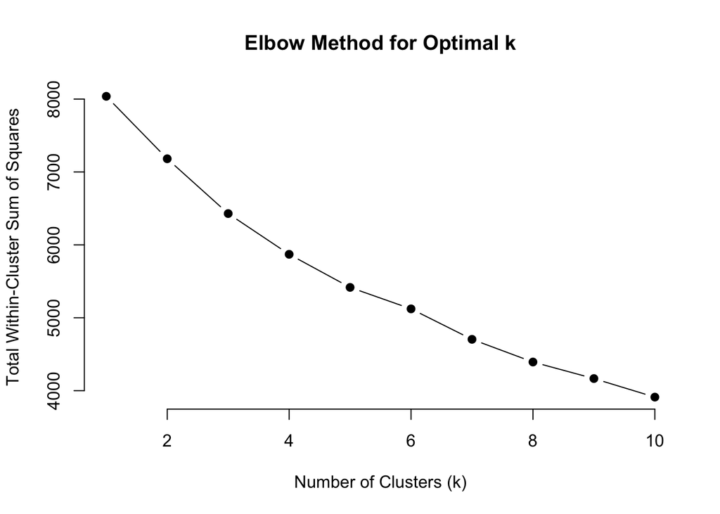

```r
# need to make the data numeric
numeric_cols <- sapply(World, is.numeric)
World_numeric <- World[, numeric_cols]

World_scaled <- scale(World_numeric)
World_scaled[is.na(World_scaled)] <- 0



wss <- sapply(1:10, function(k) {
  kmeans(World_scaled, centers = k, nstart = 25)$tot.withinss
})

# plot for elbow method
plot(1:10, wss, type = "b", pch = 19, frame = FALSE,
     xlab = "Number of Clusters (k)",
     ylab = "Total Within-Cluster Sum of Squares",
     main = "Elbow Method for Optimal k")
```

```r
# finding clusters
k <- 5  # chosen with elbow method
kmeans_result <- kmeans(World_scaled, centers = k, nstart = 25)

# include cluster in data set
World$Cluster <- kmeans_result$cluster


pca_result <- prcomp(World_scaled)
pca_data <- data.frame(pca_result$x[, 1:2], Cluster = as.factor(World$Cluster), Country = World$country)

kmeans_result= ggplot(pca_data, aes(x = PC1, y = PC2, color = Cluster, label = Country)) +
  geom_point(size = 2) +
  geom_text(vjust = 1.5, size = 2.5) +
  labs(title = "k-Means Clustering Visualization (PCA)", x = "Principal Component 1", y = "Principal Component 2") +
  theme_minimal()
```

### **Identify the largest potential for connections between countries based on their demographic and geographic characteristics.**

Using a combination of a gravity model and the parameters from the world data-set the Random forest is used to predict the most important features for large data transfer. This was made without the actual connections due to issues with the igraph object. The random forest model is a machine learning method which does not require normally distributed data to predict the potential importance of a feature.

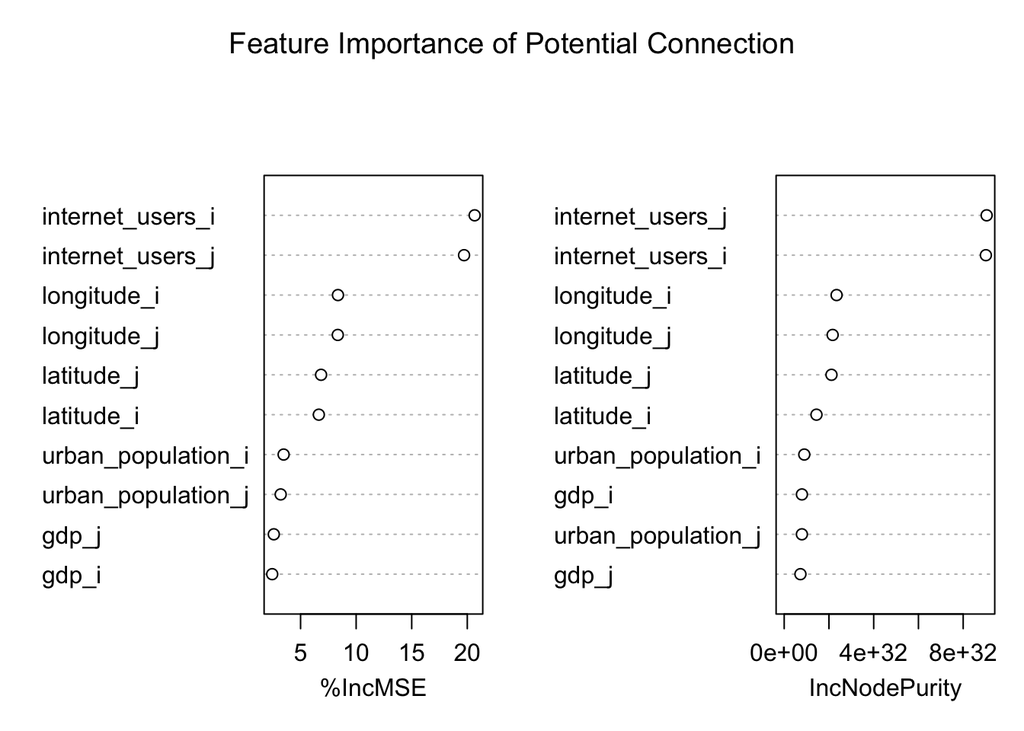

```r
# Make the pairs
country_pairs <- expand.grid(country_i = World$country, country_j = World$country) %>%
  filter(country_i != country_j)  # only include differnet countries

# join the features
pairs_data <- country_pairs %>%
  left_join(World, by = c("country_i" = "country")) %>%
  rename(
    gdp_i = gdp,
    internet_users_i = InternetUsers_NumberOfInternetUsers,
    urban_population_i = Urban.Pop..,
    latitude_i = latitude,
    longitude_i = longitude,
    role_i = role)

# Join features for 'country_j'
pairs_data <- pairs_data %>%
  left_join(World, by = c("country_j" = "country")) %>%
  rename(
    gdp_j = gdp,
    internet_users_j = InternetUsers_NumberOfInternetUsers,
    urban_population_j = Urban.Pop..,
    latitude_j = latitude,
    longitude_j = longitude,
    role_j = role
  )

# potential connections importance based on reverse gravity model
pairs_data <- pairs_data %>%
  mutate(
    distance = sqrt((latitude_i - latitude_j)^2 + (longitude_i - longitude_j)^2),  # rough distance
    potential_importance = (internet_users_i * internet_users_j) / (distance + 1)  # Prevent division by zero
  )

# Prep for rf
predictors <- pairs_data %>%
  select(gdp_i, internet_users_i, urban_population_i, latitude_i, longitude_i,
         gdp_j, internet_users_j, urban_population_j, latitude_j, longitude_j)
# cant process NA values
predictors[is.na(predictors)] <- 0
# Define the response variable: potential importance of a connection
response <- pairs_data$potential_importance

# Fit the Random Forest Model
rf_model <- randomForest(x = predictors, y = response, ntree = 500, importance = TRUE)


Feature_importance= varImpPlot(rf_model, main = "Feature Importance of Potential Connection")
```

```r
# use the rf to predict importance by pair
pairs_data$predicted_importance <- predict(rf_model, newdata = predictors)

# select the top importance
top_connections <- pairs_data %>%
  arrange(desc(predicted_importance)) %>%
  slice(1:10)
```

# Results

### **H1**

#### Network map

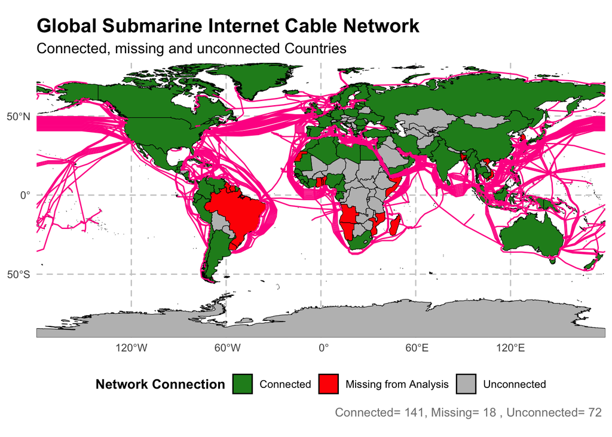

```r
Network_map
```

This map shows the routes of all undersea internet cables and highlights the association of countries to the network. The 141 Countries highlighted in green are connected to at least one other country by undersea internet cables. The 72 grey countries are those with no connection to the network. There were 18 countries which have visible connections but have not been included in the analysis, these are highlighted in red. These include Brazil, Bangladesh, Vietnam, Congo and South Korea as well as others.

#### Connected Network

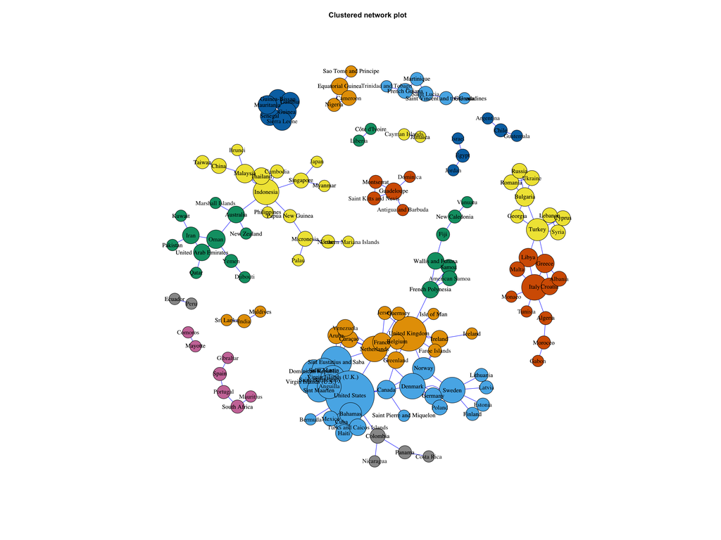

```r
plot(
  Network_analysis_network,
  layout = layout_with_fr(Network_analysis_network),
  vertex.size = V(all_countries)$size,
  vertex.color = as.factor(membership(clusters)),
  vertex.label.cex = 1,
  vertex.label.color = "black",
  edge.color = "blue",
  main = "Clustered network plot")
```

This network plot shows how countries are connected within the network of undersea internet cables. The blue edges between countries represent a connection of at least one undersea internet cable. The node colours are representative of the cluster it belongs to, some sub-networks are large enough to include multiple clusters within them. The three large sub-networks account for the majority of countries within the undersea internet cable network. There are smaller sub-networks which include less countries as well as some dyad and tryad sub-networks. The size of nodes in this plot is defined by the degree centrality of each country, showing the number of countries connected to a given country by undersea internet cables. The United States has the largest degree centrality, followed by the United Kingdom.

#### GLM connection

```r
summary(connection_model)
```

```
##
## Call:
## glm(formula = network_connection ~ APEC + InternetUsers_PctOfPopulationUsingInternet +
##     Urban.Pop.. + Asia + Europe + South.America + longitude +
##     latitude, data = World)
##
## Coefficients:
##                                              Estimate Std. Error t value
## (Intercept)                                 0.3097640  0.0659165   4.699
## APEC                                        0.2933512  0.1305457   2.247
## InternetUsers_PctOfPopulationUsingInternet  0.0029765  0.0012877   2.311
## Urban.Pop..                                 0.3824608  0.1273790   3.003
## Asia                                       -0.2082111  0.1027724  -2.026
## Europe                                     -0.3313859  0.1205654  -2.749
## South.America                              -0.3752398  0.1597752  -2.349
## longitude                                  -0.0006402  0.0005399  -1.186
## latitude                                    0.0028987  0.0019075   1.520
##                                            Pr(>|t|)
## (Intercept)                                4.68e-06 ***
## APEC                                         0.0257 *
## InternetUsers_PctOfPopulationUsingInternet   0.0218 *
## Urban.Pop..                                  0.0030 **
## Asia                                         0.0440 *
## Europe                                       0.0065 **
## South.America                                0.0198 *
## longitude                                    0.2370
## latitude                                     0.1301
## ---
## Signif. codes:  0 '***' 0.001 '**' 0.01 '*' 0.05 '.' 0.1 ' ' 1
##
## (Dispersion parameter for gaussian family taken to be 0.204556)
##
##     Null deviance: 53.32  on 221  degrees of freedom
## Residual deviance: 43.57  on 213  degrees of freedom
##   (9 observations deleted due to missingness)
## AIC: 288.53
##
## Number of Fisher Scoring iterations: 2
```

#### Urban population

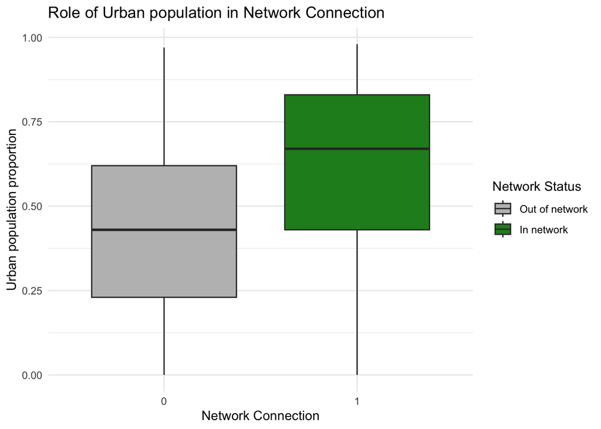

```r
Urban_population_con
```

#### APEC network connection

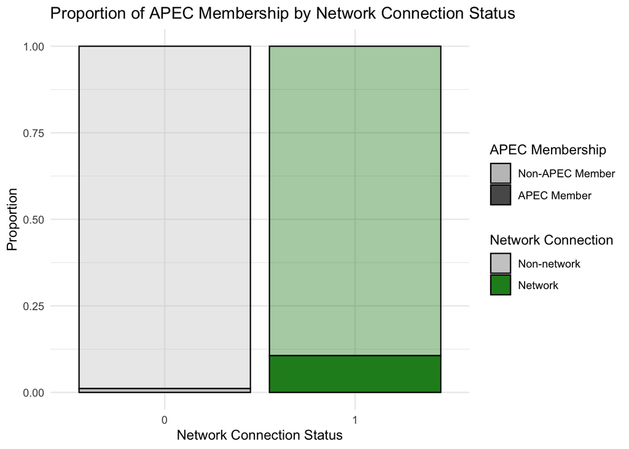

```r
APEC_stacked_plot_connect
```

The proportion of countries in APEC between in and out of the network groups are compared in this plot. For countries within the network there are a higher proportion of APEC members, with values around 0.12. This value is lower, at 0.01 for countries outside of the network. While the proportion of APEC members is low for the entire group of countries in the network, it is higher than the number of members outside of the network.

**Role of Internet in network connection**

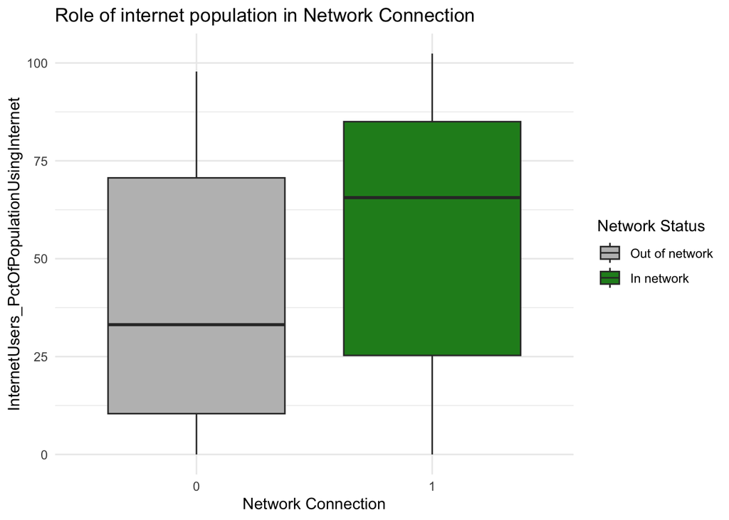

```r
InternetUsers_PctOfPopulationUsingInternet_con
```

This box plot shows that the percentage of internet users in the countries included in the network are higher than those not in the network. The mean percentage of the population with internet access in the network is 65% whereas outside of the network its 35%.

**Role of South America in network connection**

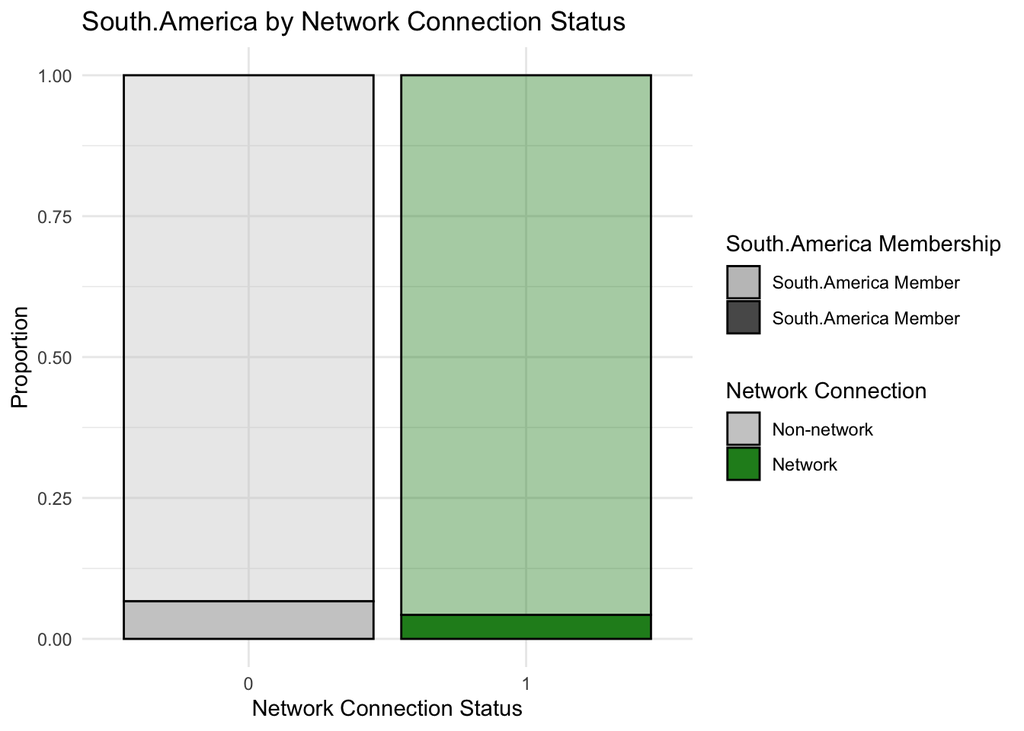

```r
Samerica_stacked_plot_connect
```

The bar plot shows that there is slightly fewer South American countries in the network than when compared with the proportion outside of the network.

### **H2**

#### Network status map

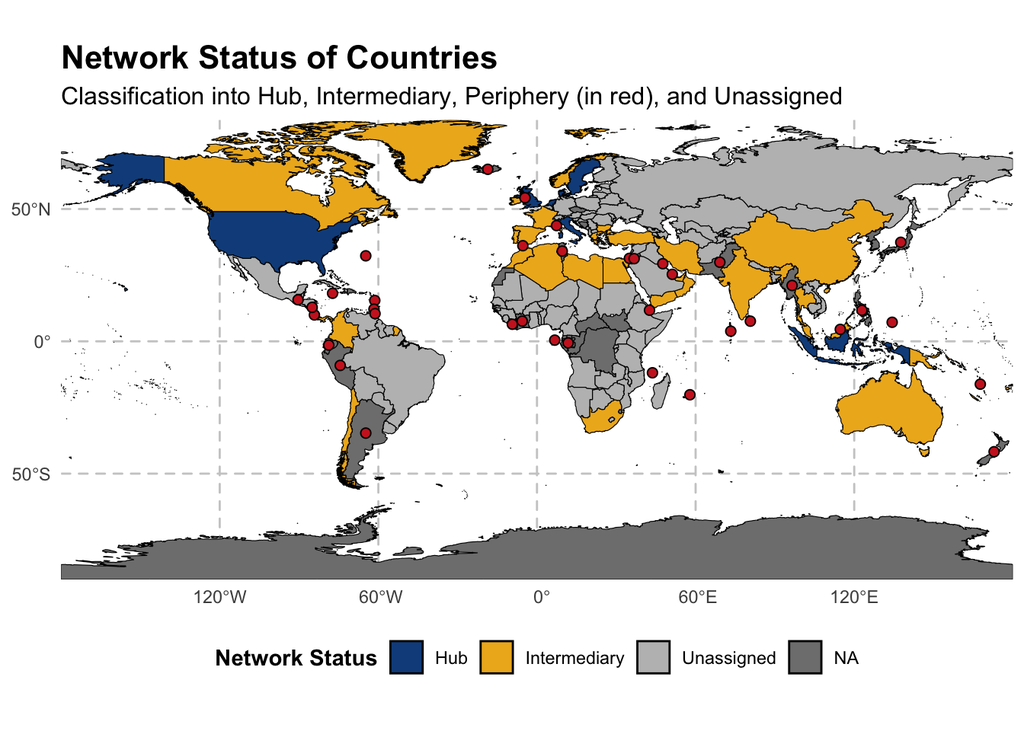

```r
Structure_map
```

#### Hubs

```r
summary(hub_model)
```

```
##
## Call:
## glm(formula = hub ~ +EU + InternetUsers_NumberOfInternetUsers +
##     +Migrants..net. + coast_to_area_wri + longitude + latitude +
##     gdp, data = World)
##
## Coefficients:
##                                       Estimate Std. Error t value Pr(>|t|)
## (Intercept)                          6.245e-04  1.515e-02   0.041  0.96717
## EU                                   7.824e-02  4.319e-02   1.811  0.07145 .
## InternetUsers_NumberOfInternetUsers  3.415e-10  1.198e-10   2.850  0.00478 **
## Migrants..net.                       4.460e-07  1.125e-07   3.966 9.89e-05 ***
## coast_to_area_wri                   -1.612e-05  1.209e-04  -0.133  0.89409
## longitude                           -1.534e-05  1.710e-04  -0.090  0.92861
## latitude                             1.459e-04  5.565e-04   0.262  0.79348
## gdp                                  1.046e-06  6.464e-07   1.618  0.10714
## ---
## Signif. codes:  0 '***' 0.001 '**' 0.01 '*' 0.05 '.' 0.1 ' ' 1
##
## (Dispersion parameter for gaussian family taken to be 0.02923112)
##
##     Null deviance: 7.7193  on 227  degrees of freedom
## Residual deviance: 6.4308  on 220  degrees of freedom
##   (3 observations deleted due to missingness)
## AIC: -148.52
##
## Number of Fisher Scoring iterations: 2
```

The GLM model summary shows where there are statistically significant differences between the features of countries identified as hubs and the countries which weren’t. There are two statistically significant results to a 95% confidence interval, the number of migrants hub nations take in are higher and the number of internet users are higher. EU membership is significant at a lower 90% confidence interval.

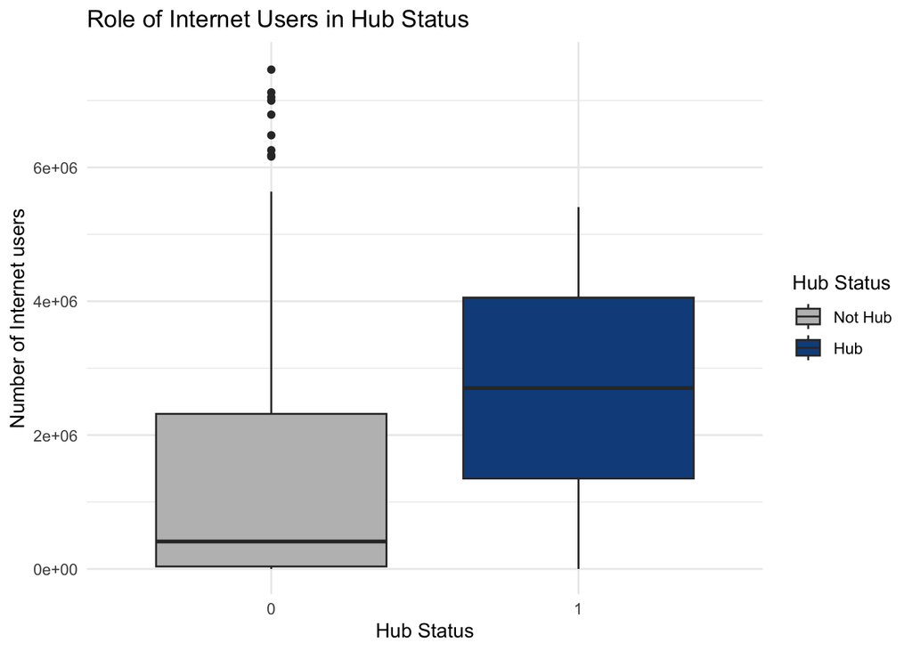

```r
Hub_internet
```

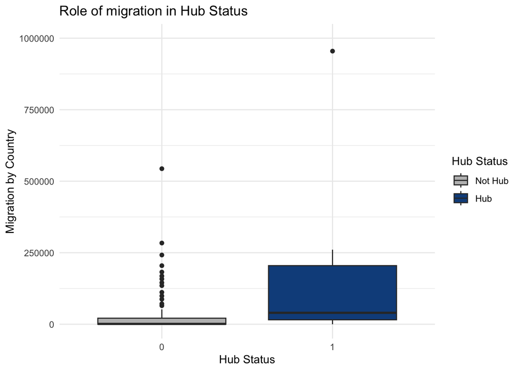

```r
Hub_mig
```

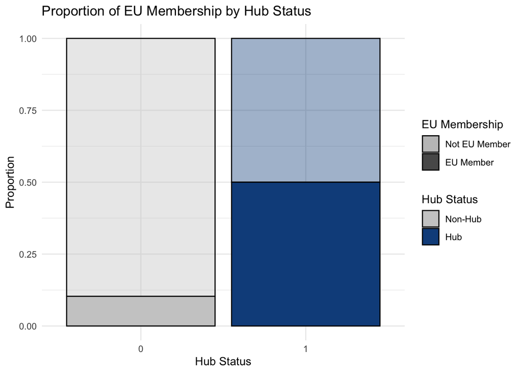

```r
EU_stacked_plot_hub
```

The plots comparing the values of statistically significant features between hub and non hub nations are shown. For Internet users and population plots, outliers have been cropped to focus on the IQR. For Hub nations, the number of people online is higher than for non-hub nations. Half of hub nations are in the EU. When compared to the proportion of non-hub nations in the EU at around 10% it can be seen hub nations are more European. Additionally, hub nations have a higher net migration value.

#### Intermediaries

```r
summary(inter_model)
```

```
##
## Call:
## glm(formula = intermediary ~ APEC + EU + Population..2020. +
##     gdp + coast_to_area_wri + longitude + latitude, data = World)
##
## Coefficients:
##                     Estimate Std. Error t value Pr(>|t|)
## (Intercept)        1.337e-01  3.351e-02   3.991 8.97e-05 ***
## APEC               1.753e-01  1.059e-01   1.656   0.0992 .
## EU                 5.071e-02  9.466e-02   0.536   0.5927
## Population..2020.  4.675e-10  1.915e-10   2.442   0.0154 *
## gdp                1.889e-06  1.368e-06   1.381   0.1687
## coast_to_area_wri -2.823e-05  2.640e-04  -0.107   0.9149
## longitude          2.121e-04  3.742e-04   0.567   0.5714
## latitude          -1.061e-03  1.224e-03  -0.867   0.3868
## ---
## Signif. codes:  0 '***' 0.001 '**' 0.01 '*' 0.05 '.' 0.1 ' ' 1
##
## (Dispersion parameter for gaussian family taken to be 0.1388821)
##
##     Null deviance: 32.982  on 227  degrees of freedom
## Residual deviance: 30.554  on 220  degrees of freedom
##   (3 observations deleted due to missingness)
## AIC: 206.79
##
## Number of Fisher Scoring iterations: 2
```

**Intermediary population**

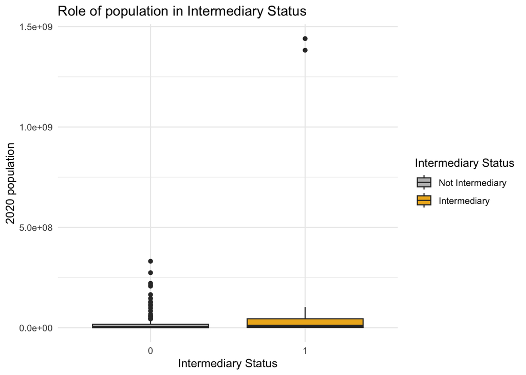

```r
inter_pop
```

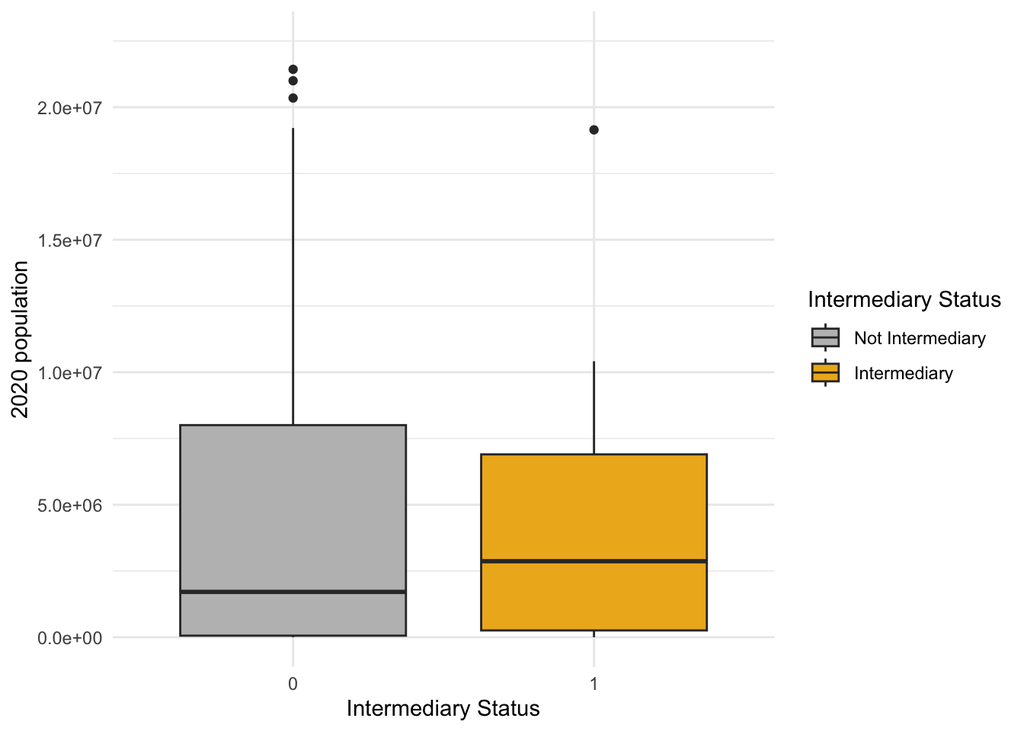

```r
inter_pop_crop
```

The box plot comparing Populations between intermediary and non-intermediary show that while there is a higher mean population across the intermediary countries, the upper quartile of the non-intermediary is higher. This is potentially influenced by India and China who can be seen with higher population values in the non-cropped box plot. APEC membership is higher in the Intermediary group than it is outside of it.

**Intermediary APEC**

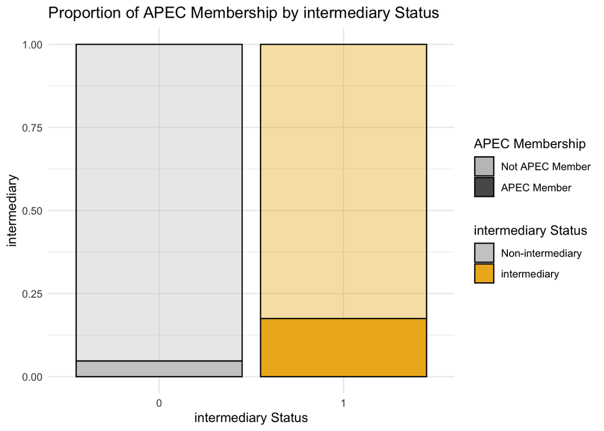

```r
APEC_stacked_plot
```

The proportion of countries as members of APEC is higher for intermediaries than other countries. Within the intermediaries its around 0.15 and outside it is around 0.04.

#### K means

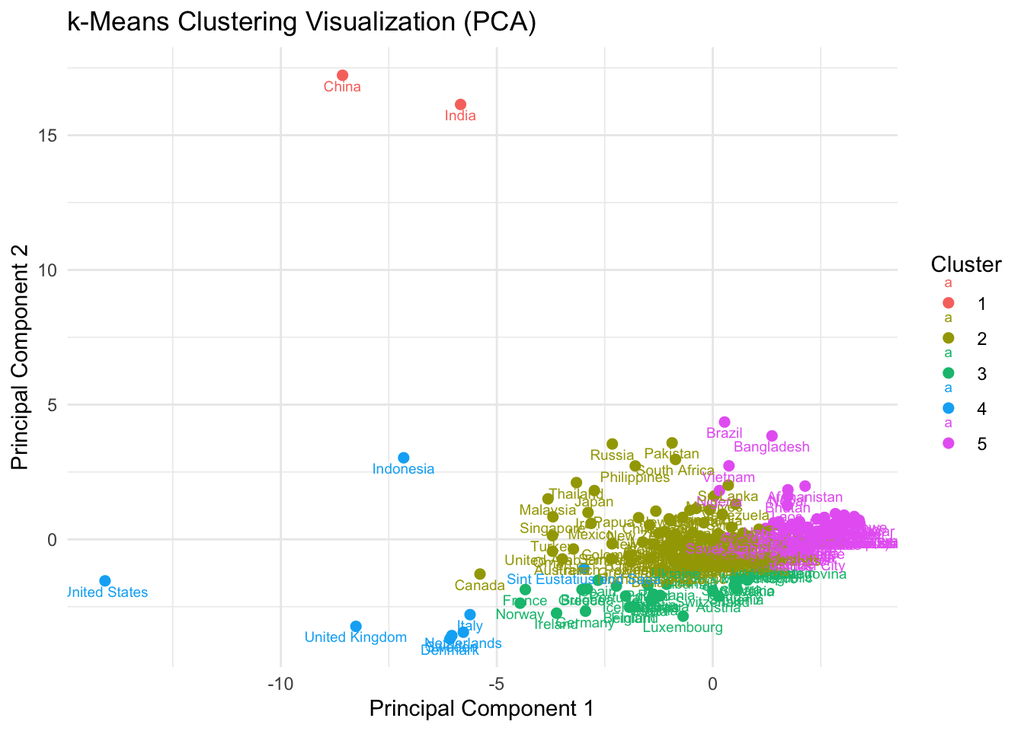

```r
kmeans_result
```

```r
print(pca_result$rotation[, 1:2])
```

```
##                                                     PC1          PC2
## APEC                                       -0.175179334  0.156602389
## EU                                         -0.130791359 -0.203544281
## BRICS                                      -0.087736438  0.331437439
## NAFTA                                      -0.144974787 -0.021552123
## ASEAN                                      -0.068642641  0.091725426
## GCC                                        -0.043329569 -0.011357337
## SAARC                                       0.002402674  0.194409655
## SCM                                         0.007223510  0.048090446
## COMESA                                      0.109080817  0.039289557
## SACU                                        0.056160125  0.040314521
## gdp                                        -0.205600812 -0.186868914
## InternetUsers_NumberOfInternetUsers        -0.180595100  0.401118088
## InternetUsers_PctOfPopulationUsingInternet -0.231622606 -0.073373453
## InternetTraffic12312020                    -0.184921856  0.395817524
## Population..2020.                          -0.159675769  0.413309118
## Urban.Pop..                                -0.186826085 -0.092368808
## Migrants..net.                             -0.120285431 -0.223378171
## network_connection                         -0.276046027 -0.034548725
## degree_centrality                          -0.309586436 -0.102618461
## subnetwork_distance                        -0.287466640 -0.054482573
## betweenness_centrality                     -0.283773578 -0.084209000
## pagerank                                   -0.341345820 -0.036864554
## coast_to_area_wri                          -0.005061054  0.003672912
## longitude                                  -0.006907567  0.132890683
## latitude                                   -0.152350226 -0.149112489
## Africa                                      0.149884470  0.052173367
## Asia                                       -0.060922049  0.211733079
## Europe                                     -0.116764783 -0.230309463
## North.America                              -0.017398846 -0.048184236
## Oceania                                     0.011250814  0.011355087
## South.America                               0.020673687  0.043868951
## hub                                        -0.225628206 -0.097436144
## intermediary                               -0.189025633  0.074258891
## periphery                                  -0.021357522  0.019890417
## unassigned                                  0.247825059 -0.036888556
```

When plotted, this shows that cluster four has high network connectivity, and relatively low population. Cluster five has both low connectivity and low population. Cluster two and three have better connectivity but a larger population for group two. Then cluster one appears to be a high population, high connectivity outlier.

### **H3**

**Random forest**

```r
print(rf_model)
```

```
##
## Call:
##  randomForest(x = predictors, y = response, ntree = 500, importance = TRUE)
##                Type of random forest: regression
##                      Number of trees: 500
## No. of variables tried at each split: 3
##
##           Mean of squared residuals: 2.721856e+28
##                     % Var explained: 55.58
```

```r
Feature_importance
```

```
##                      %IncMSE IncNodePurity
## gdp_i               2.447081  7.921391e+31
## internet_users_i   20.661852  9.014325e+32
## urban_population_i  3.475448  8.974775e+31
## latitude_i          6.642635  1.442368e+32
## longitude_i         8.364416  2.342000e+32
## gdp_j               2.591334  7.257085e+31
## internet_users_j   19.709926  9.048443e+32
## urban_population_j  3.210288  7.909320e+31
## latitude_j          6.845218  2.113428e+32
## longitude_j         8.348504  2.165433e+32
```

```r
print(top_connections %>% select(country_i, country_j, predicted_importance))
```

```
##     country_i  country_j predicted_importance
## 1       China      India         2.349684e+16
## 2       India      China         2.296798e+16
## 3  Bangladesh      India         7.021871e+15
## 4       India Bangladesh         6.629057e+15
## 5    Pakistan      India         6.385890e+15
## 6  Bangladesh      China         6.326785e+15
## 7       India   Pakistan         6.135810e+15
## 8       China Bangladesh         5.646494e+15
## 9    Pakistan      China         5.206828e+15
## 10      China   Pakistan         5.011831e+15
```

# Discussion

### **H2**

Understanding the roles countries play within thier sub-network allows for further development of the network to be efficient and resilient. Hub nodes are at highest risk to targeted attack, if they are removed from the network, many countries will feel the impact. Additionally, the tapping of information through these hub nations will pose the largest risk to privacy. Intermediary nodes make up the largest proportion of assigned nodes, these are identified as being important in the network as a large amount of shortest paths travel through them. This makes them vulnerable to random attacks, through natural disaster such as landslides, earthquakes, animal or accidental human induced damage. There are a large number of these connections and if they break the network must be quickly repaired.

The GLM model shows that hub nations have higher EU membership, higher migration in and higher populations of internet users. EU countries may be more open to connections as they are already in a trading group. The higher rate of internet users in the hub countries may be a result of the connection to the network rather than a causal effect the other way round. Intermediary nations have higher populations and rates of APEC membership than non-intermediary ones. This suggests that again links are required in the network between countries of high populations. Additionally, APEC membership may represent a higher rate of connection to other countries. India and China appear to be driving this relationship as their populations are much higher than any other nations.

The k means clustering suggests that the most important factors in defining the connections within the network are population based rather than geographical. It also highlights the importance of network connectivity measures in grouping countries, which strengthens the classifications of the structural position in the network. An example of this can be seen with cluster four matching very closely to the hubs identified by network measures as well as India and China being identified as outliers. The PCA analysis found population, number of internet users, and trade groups as useful groupings for countries. The k means clustering reinforces the findings of the GLM models and helps answer the hypothesis suggesting that population and trading groups are the most important factors in the structure of the undersea cable network.

Overall the work suggests that European, Asian and South american regions are underrepresented in the network, and that some expansion is required for these areas to meet international connectivity rates. The results also demonstrate that highly connected nations are more welcoming of trade and migration. Which may be an indicator of globalization playing an important role in the network. These highly connected countries will be at the highest risk from targeted attack as the large amounts of data will be the most exposed at these connections. Connections from hub and intermediary nations such as the USA, UK, China and India need the highest level of protection through increasing the number of connections from these nations for network resilience against cable breakage.

### **H3**

The random forest predicts high value connections based on demographic and geographic factors. Which is useful for both maintaining current connections and direct where new connections would be most effective. The large population of internet users combined with relatively close proximity is increasing the value of connections within Asia. This can be used to highlight the importance of all the connections within the Asian region connecting these nations as the rf estimates they have the most important data flows.

### **Limitations of analysis**

The main limitation of this analysis is the removal of the 18 nations when the network for analysis was created. This means the influence of them can’t be included in the GLM or K means, reducing the accuracy of the results.

There may be some bias in the data where periphery nations are more likely to be in the North American continent. Where the name of small islands owned/ governed by the US were not recognised in the data-set of country information it was changed to being the USA. This will increase the number of small islands recognised as being in the Northern American continent and increase the population figures as the US is much larger than small islands.

The random forest model lacks connection to the grid, this means its results are somewhat theoretical. The cost and logistics of installing cables is not included and the distance projections have a bias towards nations close in terms of latitude and longitude, but across the pacific ocean values of longitude will jump from -180 to 180 and be close in reality.

Further study could focus on the characteristics driving connections through gravity modelling. A basic gravity model based on the internet traffic of each country could be used to identify where there are close countries with high internet use which could benefit from a new undersea internet cable connection. The gravity equation would need to be adjusted so flow is highest between high and high nations rather than high and low ones. It would also be useful in identifying the connections with the highest flow and therefore most risk to being deliberately tapped or broken.

# Conclusion

This work demonstrates how the undersea internet cable network is driven by factors more diverse than geographical location alone. Demographics play a more important role in the importance of connections than geography.

These results highlight the importance of increasing the network connectivity especially for countries with lower urban populations. It also shows the role countries with large populations play within the undersea cable network. This can be used to guide the implementation of new network connections based on population and trade links, results reinforced by the k means clustering analysis.

# **Bibliography**

'European Union' (2024) *Wikipedia*. Available at: https://en.wikipedia.org/w/index.php?title=European_Union&oldid=1260536099 (Accessed: 3 December 2024).

Ross, M. (2014) 'Understanding Interconnectivity of the Global Undersea Cable Communications Infrastructure and its Implications for International Cyber Security', *SAIS Review of International Affairs*, 34(1), pp. 141–155.

Sugadev, A. (2016) 'India's critical position in the global submarine cable network: an analysis of Indian law and practice on cable repairs', *Indian Journal of International Law*, 56(2), pp. 173–200. Available at: https://doi.org/10.1007/s40901-017-0050-y.